# The MIBE-LSU challenge

Om Ajay Karthik

3/10/2021

This report consists of detailed analyses of food delivery scene in London evaluated based on both the datasheets, one with the restaurant data and another with restaurant delivery time details. Using R, I have tried to analyze various relationships and extract the required details. I am presenting the detailed analysis below.

Restaurants Information In this section, you will analyze the Restaurant information dataset with the objective of answering the following questions:

1. Present a column chart with the top 10 neighborhoods by the number of restaurants.
2. Present a column chart with the top 10 neighborhoods by restaurant review score.
3. Compute the top 10 biggest chains. Present the results in a tabular format. (Use the column rest_brand to determine restaurants of the same brand)
4. Compute the average menu price and the number of menu items for each restaurant. (The rest_menu_item_price column is a list of characters. You might want to use the by_row and map functions)
5. Present in a bar chart the number of items on the menu for the five most expensive and cheapest restaurants. (The number of items can be determined by counting the elements in the rest_menu_item_price column)

Installing necessary packages

```r
 #install.packages('ggplot2')
 #install.packages('dplyr')
 #install.packages("tidyverse")

 #install.packages("xlsx")
 #install.packages('expss')
 #install.packages('gridExtra')
 #install.packages('purrrlyr')
 #install.packages('ggpubr')
 #install.packages('data.table')
```

Importing necessary libraries

```r
library(ggpubr)
```

```r
library(ggplot2)
library(dplyr)
library(gridExtra)
library(tidyverse)
library(purrrlyr)
library(data.table)
```

Imporing datasets

```r
resturants_mibe <- readRDS("C:/Users/Om Ajay Karthik/Desktop/LSU/resturants-mibe.rds")
delivery_mibe <- readRDS("C:/Users/Om Ajay Karthik/Desktop/LSU/delivery-mibe.rds")
```

### 1. Present a column chart with the top 10 neighborhoods by the number of restaurants.

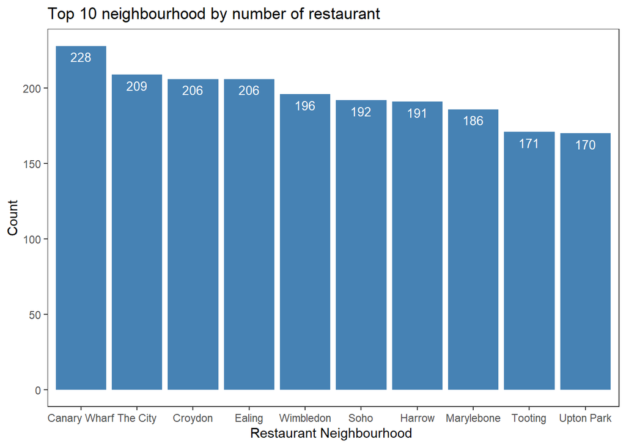

```r
freq_rest_neighborhood= count(resturants_mibe, rest_neighborhood)
freq_rest_neighborhood_desc <-freq_rest_neighborhood[order(-freq_rest_neighborhood$n),]
freq_rest_neighborhood_desc_top_n = head(freq_rest_neighborhood_desc, n=10)

ggplot(freq_rest_neighborhood_desc_top_n, aes(x = reorder(rest_neighborhood, -n), y = n)) +
  geom_bar(stat = "identity") +
  geom_bar(stat="identity", fill="steelblue")+
  geom_text(aes(label=n), vjust=1.6, color="white", size=3.5)+
  labs(title = "Top 10 neighbourhood by number of restaurant") +
  xlab("Restaurant Neighbourhood ") +
  ylab("Count") +
  theme_test()
```

### 2. Present a column chart with the top 10 neighborhoods by restaurant review score.

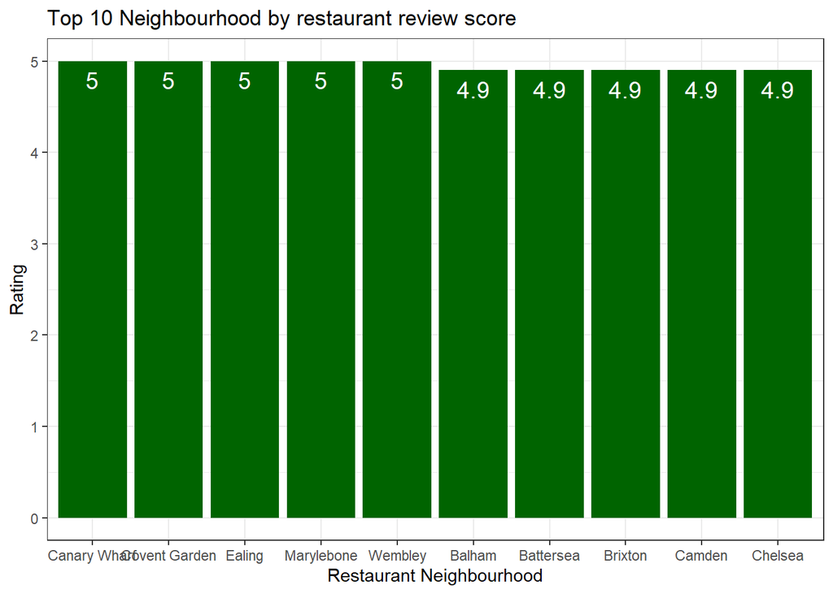

```r
topn_by_review = head(resturants_mibe  %>%
  filter(!is.na(rest_rating))  %>% arrange(-rest_rating,rest_neighborhood) %>% select(rest_neighborhood,rest_rating) %>% unique(),n=10)

ggplot(topn_by_review, aes(x = reorder(rest_neighborhood, -rest_rating), y = rest_rating)) +
  geom_bar(stat="identity", fill="darkgreen")+
  geom_text(aes(label=rest_rating), vjust=1.6, color="white", size=5)+
  labs(title = "Top 10 Neighbourhood by restaurant review score") +
  xlab("Restaurant Neighbourhood") +
  ylab("Rating") +
  theme_bw()
```

### 3. Compute the top 10 biggest chains. Present the results in a tabular format. (Use the column rest_brand to determine restaurants of the same brand)

```r
graphics.off()
biggest_chains = resturants_mibe %>% filter(!is.na(rest_brand)) %>%  count(.,rest_brand)
names(biggest_chains)[1] <- "Restaurant_Brand"
names(biggest_chains)[2] <- "Count"
biggest_chains_desc <-biggest_chains[order(-biggest_chains$Count),]
biggest_chains_desc_top_n = head(biggest_chains_desc, n=10)
```

Custom display of of the table since Rmd has a bug while displaying this code:::grid.draw(biggest_chains_desc_top_n):::

```r
writeLines("td, th { padding : 6px } th { background-color : brown ; color : white; border : 1px solid white; } td { color : brown ; border : 1px solid brown }", con = "mystyle.css")
dset1 <- head(biggest_chains_desc_top_n,n=10)
knitr::kable(dset1, format = "html")
```

| Restaurant_Brand | Count |
| --- | --- |
| Get drinks delivered | 42 |
| KFC | 42 |
| PizzaExpress | 42 |
| Pret A Manger | 33 |
| Burger King | 22 |
| itsu | 22 |
| Pure | 21 |
| Wasabi | 20 |
| LEON | 19 |
| Papa John’s | 18 |

### 4. Compute the average menu price and the number of menu items for each restaurant (The rest_menu_item_price column is a list of characters. You might want to use the by_row and map functions)

```r
resturants_mibe_rest_menu_item_price_mean = resturants_mibe %>%
  select(rest_name,rest_brand,rest_menu_item_price) %>%
  by_row(..f = function(this_row) {
    this_row[3] %>% unlist %>% mean})

names(resturants_mibe_rest_menu_item_price_mean)[4] <- "Average_price"

resturants_mibe_rest_menu_item_price_length = resturants_mibe %>%
  select(rest_name,rest_brand,rest_menu_item_price) %>%
  by_row(..f = function(this_row) {
    this_row[3] %>% unlist %>% length()})

names(resturants_mibe_rest_menu_item_price_length)[4] <- "Count_of_menu_items"
```

#### Average menu price for each resturant(printing only head of 5(top 5))

```r
dset1 <- head(resturants_mibe_rest_menu_item_price_mean,n=5)
knitr::kable(dset1, format = "html")
```

| rest_name | rest_brand | rest_menu_item_price | Average_price |
| --- | --- | --- | --- |
| Baba Wali Hendon Broadway | NA | 2.80, 4.20, 5.60, 4.20, 5.60, 14.00, 16.80, 4.20, 14.00, 14.00, 14.00, 200.00, 168.00, 84.00, 14.00, 14.00, 11.20, 11.20, 49.00, 14.00, 16.80, 16.80, 11.20, 12.60, 16.80, 42.00, 50.40, 14.00, 12.60, 1… | 17.05414 |
| Burger & Lobster | Burger & Lobster | 0.0, 1.0, 1.5, 1.5, 5.0, 3.0, 25.0, 0.0, 38.0, 0.0, 0.0, 12.5, 9.5, 0.0, 1.5, 1.5, 1.5, 5.0, 5.0, 12.0, 0.0, 75.0, 0.0, 0.0, 27.0, 8.5, 0.0, 0.0, 1.0, 5.0, 3.0, 17.0, 0.0, 33.0, 22.0, 10.0, 0.0, 0.0, … | 6.42623 |
| Afta Eats | NA | 7.49, 5.19, 0.00, 7.49, 5.19, 0.65, 7.49, 5.19, 1.30, 1.49, 5.19, 5.19, 0.00, 5.19, 6.49, 0.00, 5.19, 5.19, 5.19, 6.49, 5.19, 6.49, 5.19, 5.19, 5.19, 5.19, 5.19, 5.19, 5.19, 3.89, 3.89, 3.89, 3.89, 3.… | 4.34898 |
| Europa 2 Go Pizza | Europa 2 Go Pizza | 9.99, 13.95, 17.95, 17.95, 17.95, 24.95, 14.99, 17.99, 4.49, 4.49, 5.49, 5.49, 3.49, 3.49, 4.49, 4.49, 4.49, 4.49, 5.49, 5.49, 5.49, 1.95, 2.95, 3.00, 3.50, 3.95, 4.95, 3.95, 3.95, 4.50, 4.50, 2.50, 2… | 3.42838 |
| Julia Domna Cafe | NA | 5.53, 11.48, 13.79, 7.70, 8.33, 6.93, 9.03, 7.35, 8.33, 6.30, 4.90, 5.46, 8.12, 8.33, 9.10, 15.40, 8.12, 7.63, 7.28, 9.10, 12.60, 6.30, 6.65, 6.65, 8.05, 6.93, 8.05, 8.05, 8.33, 7.00, 9.10, 9.10, 9.10… | 7.675781 |

#### No of items on the menu for each resturant (printing only head of 5(top 5))

```r
dset1 <- head(resturants_mibe_rest_menu_item_price_length,n=5)
knitr::kable(dset1, format = "html")
```

| rest_name | rest_brand | rest_menu_item_price | Count_of_menu_items |
| --- | --- | --- | --- |
| Baba Wali Hendon Broadway | NA | 2.80, 4.20, 5.60, 4.20, 5.60, 14.00, 16.80, 4.20, 14.00, 14.00, 14.00, 200.00, 168.00, 84.00, 14.00, 14.00, 11.20, 11.20, 49.00, 14.00, 16.80, 16.80, 11.20, 12.60, 16.80, 42.00, 50.40, 14.00, 12.60, 1… | 58 |
| Burger & Lobster | Burger & Lobster | 0.0, 1.0, 1.5, 1.5, 5.0, 3.0, 25.0, 0.0, 38.0, 0.0, 0.0, 12.5, 9.5, 0.0, 1.5, 1.5, 1.5, 5.0, 5.0, 12.0, 0.0, 75.0, 0.0, 0.0, 27.0, 8.5, 0.0, 0.0, 1.0, 5.0, 3.0, 17.0, 0.0, 33.0, 22.0, 10.0, 0.0, 0.0, … | 61 |
| Afta Eats | NA | 7.49, 5.19, 0.00, 7.49, 5.19, 0.65, 7.49, 5.19, 1.30, 1.49, 5.19, 5.19, 0.00, 5.19, 6.49, 0.00, 5.19, 5.19, 5.19, 6.49, 5.19, 6.49, 5.19, 5.19, 5.19, 5.19, 5.19, 5.19, 5.19, 3.89, 3.89, 3.89, 3.89, 3.… | 49 |
| Europa 2 Go Pizza | Europa 2 Go Pizza | 9.99, 13.95, 17.95, 17.95, 17.95, 24.95, 14.99, 17.99, 4.49, 4.49, 5.49, 5.49, 3.49, 3.49, 4.49, 4.49, 4.49, 4.49, 5.49, 5.49, 5.49, 1.95, 2.95, 3.00, 3.50, 3.95, 4.95, 3.95, 3.95, 4.50, 4.50, 2.50, 2… | 389 |
| Julia Domna Cafe | NA | 5.53, 11.48, 13.79, 7.70, 8.33, 6.93, 9.03, 7.35, 8.33, 6.30, 4.90, 5.46, 8.12, 8.33, 9.10, 15.40, 8.12, 7.63, 7.28, 9.10, 12.60, 6.30, 6.65, 6.65, 8.05, 6.93, 8.05, 8.05, 8.33, 7.00, 9.10, 9.10, 9.10… | 64 |

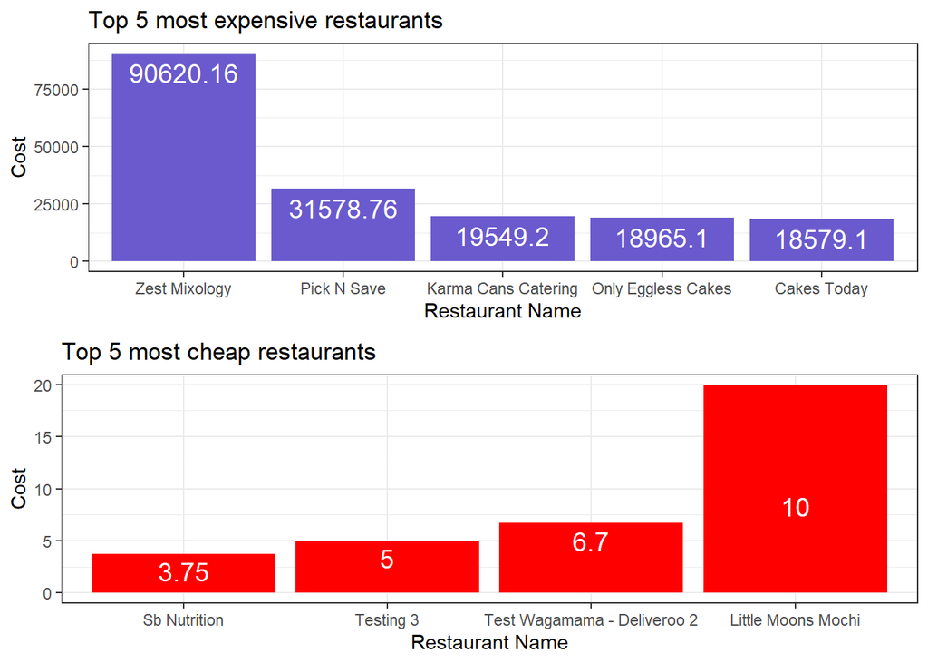

```r
menu_item_price_sum = resturants_mibe %>% select(rest_name,rest_neighborhood,rest_menu_item_price) %>% filter(!is.na(rest_menu_item_price )) %>% by_row(..f = function(this_row) {
  this_row[3] %>% unlist %>% sum()})

names(menu_item_price_sum)[4] <- "sum_of_price"
menu_item_price_sum$sum_of_price = as.numeric(as.character(menu_item_price_sum$sum_of_price))


menu_item_sum_top_5 = head(arrange(menu_item_price_sum,desc(sum_of_price)), n = 5)
menu_item_sum_bottom_5 = head(arrange(menu_item_price_sum,sum_of_price), n = 5)

expensive = ggplot(menu_item_sum_top_5, aes(x = reorder(rest_name, -sum_of_price), y = sum_of_price)) +
  geom_bar(stat="identity", fill="slateblue")+
  geom_text(aes(label=sum_of_price), vjust=1.5, color="white", size=5)+
  labs(title = "Top 5 most expensive restaurants") +
  xlab("Restaurant Name") +
  ylab("Cost") +
  theme_bw()

cheapest = ggplot(menu_item_sum_bottom_5, aes(x = reorder(rest_name, sum_of_price), y = sum_of_price)) +
  geom_bar(stat="identity", fill="red")+
  geom_text(aes(label=sum_of_price), vjust=1.4, color="white", size=5)+
  labs(title = "Top 5 most cheap restaurants") +
  xlab("Restaurant Name") +
  ylab("Cost") +
  theme_bw()


grid.arrange(expensive, cheapest)
```